# Final Project: Predicting Kickstarter Campaign Success

## PART 2: EDA, Cleaning and Imputation

### Examining Missingness

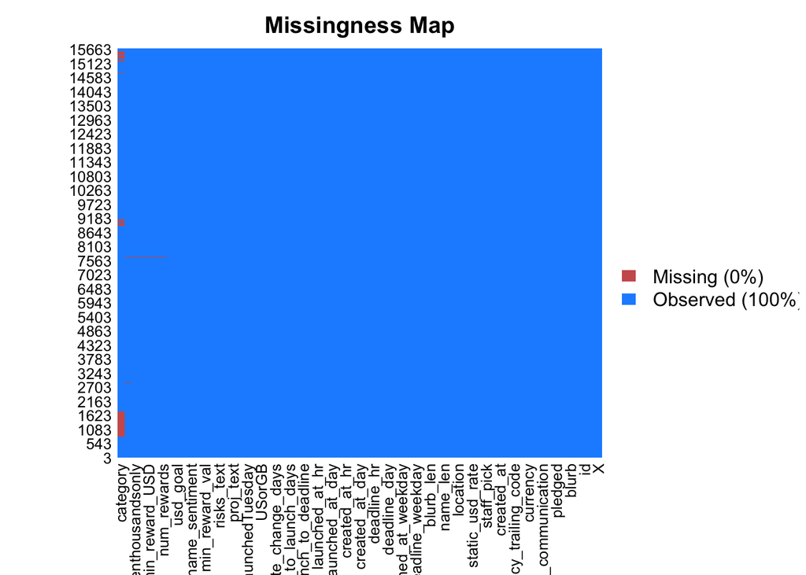

```r
missmap(data2)
```

#### Examining Missingness in Rewards-Based Variables

There appears to be some systematic missingness. Let’s take a closer look at the observations that appear to have missing values in 4 of our variables. What we find is that the four variables, “reward_sent_change”, “reward_word_change”, “num_rewards” and “min_reward_USD,” all relied on the rewards variable to be populated. In the case of these missing observations, the text of the rewards was missing, which meant that these were producing NA values. Since there are only 34 of these observations, it makes more sense to remove the observation than it does to remove the variable. Due to the sporadic nature of these projects, imputation also seems like it would not likely be accurate enough to properly represent these features. Below, these observations are removed.

```r
## The NA values involving the following variables all stem from the fact that they rely on the rewards to populate them. If the rewards were missing for an observation, then these values would be NA. Thus, we will remove these observations for the sake of seeing if these variables would help make a better model.
data2 <- data2[!(is.na(data2$reward_sent_change) & is.na(data2$reward_word_change) & is.na(data2$num_rewards) & is.na(data2$min_reward_USD)),]

## Upon further examination, it appears that these are missing the text from the rewards because they are in bullet points rather than prose. Perhaps it either took too long for the page to grab this type of text off the page before proceeding to the next page or that as a result, since there are so few of them.
sum(is.na(data2$reward_sent_change))
```

```
## [1] 27
```

```r
data2 <- data2[!is.na(data2$reward_sent_change),]
```

#### Examining Missingness in Category

```r
# sum(is.na(data2))              # = 27
# sum(is.na(data2$category))     # = 27

## Replace "" with "Unknown"
data2$category <- ifelse(is.na(data2$category), "Unknown", data2$category)
```

### Exploratory Data Analysis

Next, we will look at how some of the potential predictor variables relate to the response in order to determine whether they truly help determine whether a campaign succeeded or failed.

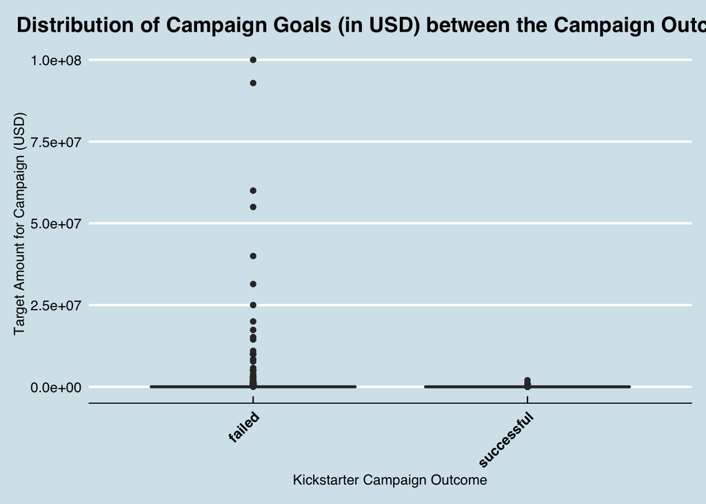

```r
ggplot(data = data2) + geom_boxplot(aes(x = state, y = usd_goal )) + theme_economist() + labs(title = "Distribution of Campaign Goals (in USD) between the Campaign Outcomes", x = "Kickstarter Campaign Outcome", y = "Target Amount for Campaign (USD)") + theme(axis.text.x = element_text(size = 10, face="bold", vjust = 1, hjust = 1, angle = 45), plot.title = element_text(hjust = 0.5))
```

```r
# ggplot(data = data2) + geom_point(aes(x = usd_goal, y = usd_pledged, color = state)) + theme_economist() + labs(title = "Distribution of the Amount Pledged (in USD) between the Campaign Outcomes", x = "Goal", y = "Amount Pledged (USD)") + theme(axis.text.x = element_text(size = 10, face="bold", vjust = 1, hjust = 1, angle = 45), plot.title = element_text(hjust = 0.5))

## Staff pick seems like a good discriminator
table(data2$staff_pick, data2$state)
```

```
##
##         failed successful
##   False   9658       4087
##   True     388       1514
```

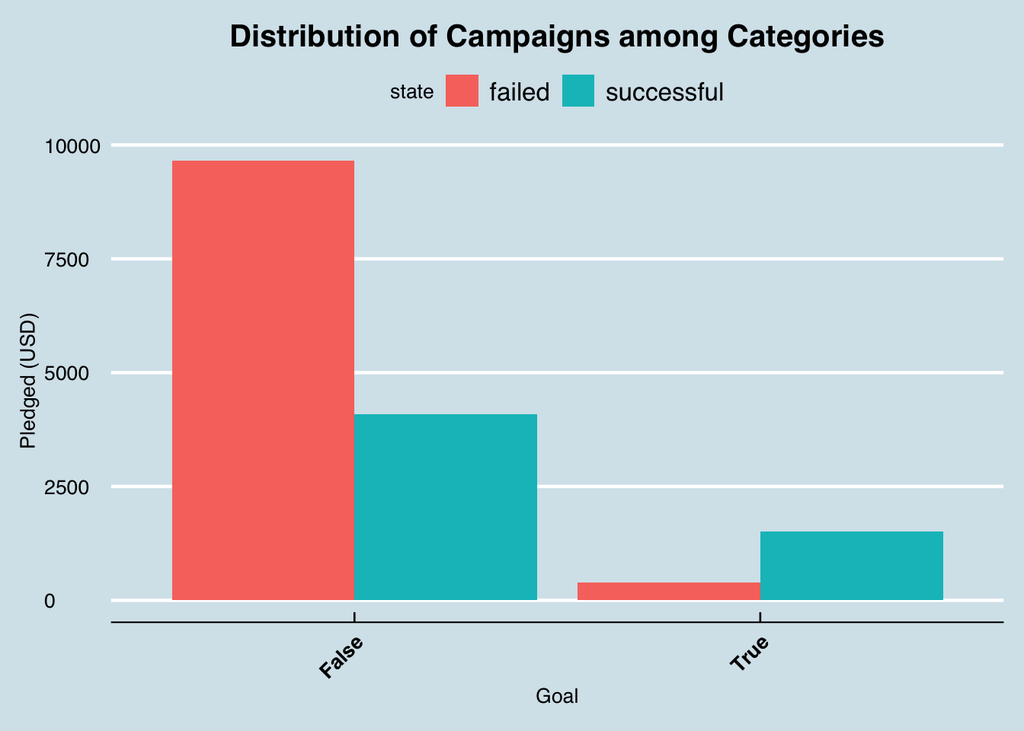

```r
ggplot(data = data2) + geom_bar(aes(x=staff_pick, fill=state),position="dodge") + theme_economist() + labs(title = "Distribution of Campaigns among Categories", x = "Goal", y = "Pledged (USD)") + theme(axis.text.x = element_text(size = 10, face="bold", vjust = 1, hjust = 1, angle = 45), plot.title = element_text(hjust = 0.5))
```

[figure not shown]

```r
ggplot(data = data2) + geom_boxplot(aes(x=state, y=num_rewards)) + theme_economist() + labs(title = "Distribution of the Number of Rewards by Outcome", y = "Number of Rewards", x = "Kickstarter Campaign Outcome") + theme(axis.text.x = element_text(size = 10, face="bold", vjust = 1, hjust = 1, angle = 45), plot.title = element_text(hjust = 0.5))
```

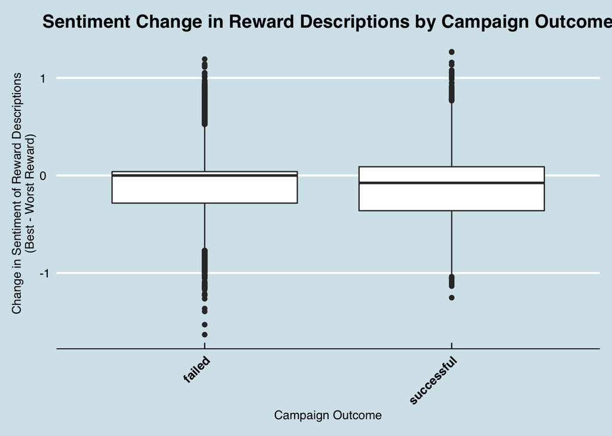

```r
## Changes in reward sentiment, which I calculated to be the sentiment of the last (usually highest) reward minus the sentiment of the first (often lowest) reward, appeared to not really help in discriminating. The same was true for the sentiment associated with the blurb about the project that you can see as you scroll through kickstarter.
ggplot(data= data2) + geom_boxplot(aes(x = state, y = reward_sent_change)) + theme_economist() + labs(title = "Sentiment Change in Reward Descriptions by Campaign Outcome", x = "Campaign Outcome", y = "Change in Sentiment of Reward Descriptions\n(Best - Worst Reward)") + theme(axis.text.x = element_text(size = 10, face="bold", vjust = 1, hjust = 1, angle = 45), plot.title = element_text(hjust = 0.5))
```

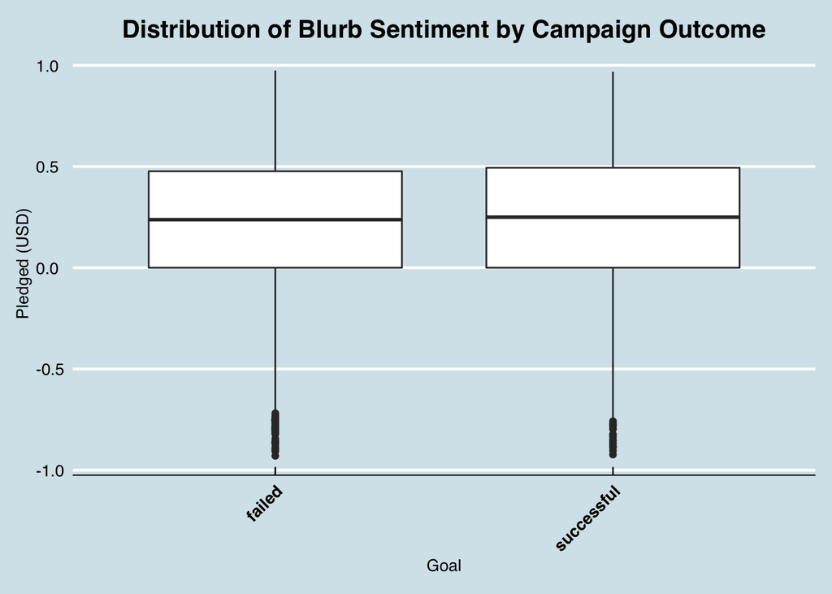

```r
ggplot(data= data2) + geom_boxplot(aes(x = state, y = blurb_sentiment))+ theme_economist() + labs(title = "Distribution of Blurb Sentiment by Campaign Outcome", x = "Goal", y = "Pledged (USD)") + theme(axis.text.x = element_text(size = 10, face="bold", vjust = 1, hjust = 1, angle = 45), plot.title = element_text(hjust = 0.5))
```

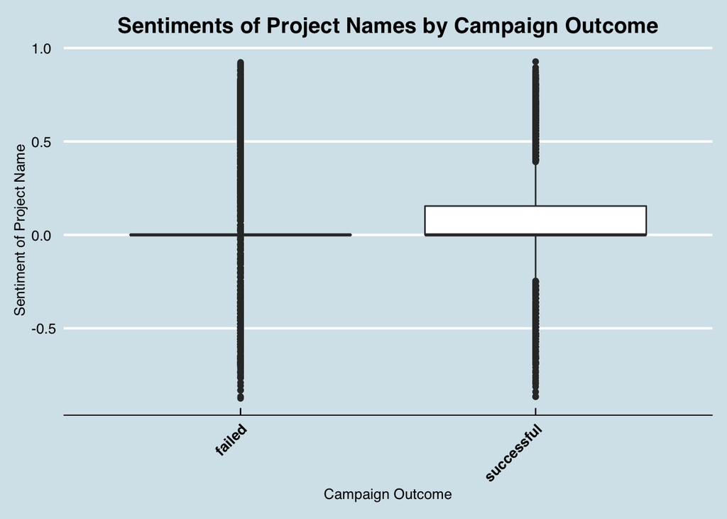

```r
## The sentiment associated with the actual name of the campaign, however, does seem to differ slightly between the two groups. It looks like the projects that succeeded had a higher proportion of more positively-associated names, compared to the projects and campaigns that failed.
ggplot(data= data2) + geom_boxplot(aes(x = state, y = name_sentiment))+ theme_economist() + labs(title = "Sentiments of Project Names by Campaign Outcome", x = "Campaign Outcome", y = "Sentiment of Project Name") + theme(axis.text.x = element_text(size = 10, face="bold", vjust = 1, hjust = 1, angle = 45), plot.title = element_text(hjust = 0.5))
```

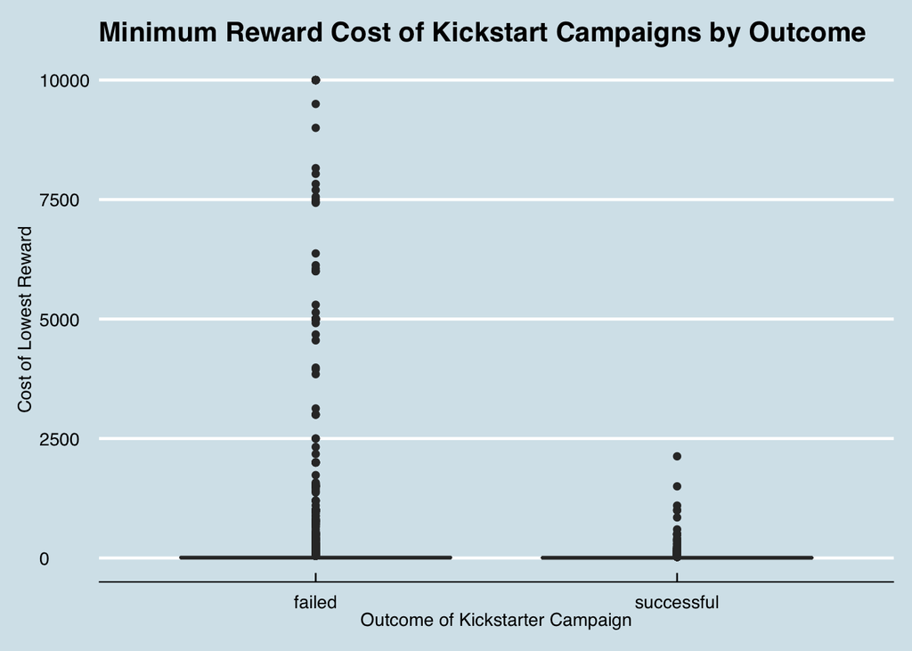

```r
# Min_reward_USD represents the smallest amount a backer can pay in order to get a reward (the lowest cost of a reward for a specific project). This did not on its face appear to be a great discriminator, however, there seems to be a great opportunity for an indicator variable, because successful projects did not have a minimum buy-in above $2500.
ggplot(data=data2) + geom_boxplot(aes(x = state, y = min_reward_USD)) + theme_economist() + labs(title = "Minimum Reward Cost of Kickstart Campaigns by Outcome", x = "Outcome of Kickstarter Campaign", y = "Cost of Lowest Reward")
```

```r
## Removing variables that may have contributed towards actual predictors but are not predictors themselves as well as predictors that do not seem promising.
data3 <- data2 %>% select(
  -currency_symbol,          # irrelevant to project performance
  -currency_trailing_code,   # irrelevant to project performance
  -SuccessfulBool,           # duplicates idea of "state" variable
  -rewards,                  # rewards themselves are each going to be unique, so not a useful predictor
  -CAorAUorNZ,               # repetitive with country
  -USorGB,                   # repetitive with country
  -story_text,               # We noted earlier that this was unfortunately an empty string for ~50% of the data
  -proj_text,                # We noted earlier that this was unfortunately an empty string for ~50% of the data
  -risks_text,               # We noted earlier that this was unfortunately an empty string for ~50% of the data
  -X,                        # Just an extra index that won't impact prediction
  -id,                       # Yet another index that won't impact prediction
  -Unnamed..0,               # Yet another index that won't impact prediction
  -disable_communication,    # There is no variance in this variable at all
  -blurb,                    # Since this is just the project caption that can be seen when browsing, it can't be used as a predictor itself
  -name,                     # this will be unique to nearly every project, so there are too many levels to use as a predictor
  -location,                 # this is a mess of a json that needs to be cleaned before being used in the model
  -static_usd_rate,          # helped generate some of our other variables, but not a good predictor in and of itself
  -created_at,               # datetime object won't work with the models
  -launched_at,              # datetime object won't work with the models
  -deadline,                 # datetime object won't work with the models
  -TOPCOUNTRY,               # correlated with country itself
  -currency,                 # correlated with country
  -name_len_clean,           # this will likely be correlated with name_len, which is just the number of characters in the name
  -blurb_len_clean,          # this will likely be correlated with blurb_len, which is just the number of characters in the blurb
  -min_reward_val,           # this held a string object before converting the value to USD
  -min_reward_val_clean,     # this held a float object in the native before converting the value to USD to have a standard measure
  -backers_count,            # a future kickstarter campaigner will not be able to control this variable, so it will not be considered.
  -launch_to_state_change,   # This was in datetime format, making it difficult for the model to handle
  -launch_to_state_change_days,  # this feature would likely overfit because people who change state early are likely to have succeeded.
  -pledged,                  # we leave off pledged and usd_pledged because these seem very close to success/failure
  -usd_pledged,              # and these features also don't really help a future project creator become successful
  -create_to_launch,         # this was a datetime object so it couldn't be used with the models properly
  -launch_to_deadline,       # this was a datetime object so it couldn't be used with the models properly
  -spotlight,
  -created_at_weekday,       # the time the project was created seemed to be a little unlikely to impact the outcome, especially since there is already information about launch and deadline dates and times
  -created_at_day,           # "
  -created_at_hr,            # "
  -created_at_yr,            # "
  -created_at_month ,        # the time the project was created seemed to be a little unlikely to impact the outcome, especially since there is already information about launch and deadline dates and times
  -category,                 # category will be difficult to use because of the number of categories >> some might not appear in training set
  -goal                      # goal will be correlated with our usd_goal variable we created to standardize currency
  )
```

```r
set.seed(1)
samps <- createDataPartition(data3$state, list=F, p =0.8)
train <- data3[samps,]
test <- data3[-samps,]

####################################
#####  Rpart Tree-Based Model  #####
####################################
success_model <- rpart( state ~ ., data=train, method = "class")
preds <- predict(success_model, newdata = test, type='class')
tab <- table(preds, test$state)
tab # Confusion Matrix for standard rpart model
```

```
##
## preds        failed successful
##   failed       1701        502
##   successful    308        618
```

```r
(tab[1,1] + tab[2,2] ) / sum(tab) # calculate accuracy
```

```
## [1] 0.7411314
```

```r
####################################
###########  C5.0 Model  ###########
####################################
library(C50)
model <- C5.0(x = train[,-1], y = train$state)
# summary(model)
preds2 <- predict(model, newdata=test,type="class")
tab2 <- table(preds2, test$state)
tab2 # confusion matrix for c5.0 model
```

```
##
## preds2       failed successful
##   failed       1629        444
##   successful    380        676
```

```r
(tab2[1,1] + tab2[2,2]) / sum(tab2) ## accuracy of the C5.0 model
```

```
## [1] 0.7366571
```

```r
####################################
###########  KNN Model  ############
####################################

## Subset to only include numeric variables and then testing a knn model
names(train)
```

```
##  [1] "state"                   "country"
##  [3] "staff_pick"              "name_len"
##  [5] "blurb_len"               "deadline_weekday"
##  [7] "launched_at_weekday"     "deadline_month"
##  [9] "deadline_day"            "deadline_yr"
## [11] "deadline_hr"             "launched_at_month"
## [13] "launched_at_day"         "launched_at_yr"
## [15] "launched_at_hr"          "create_to_launch_days"
## [17] "launch_to_deadline_days" "LaunchedTuesday"
## [19] "DeadlineWeekend"         "num_rewards"
## [21] "min_reward_USD"          "name_sentiment"
## [23] "blurb_sentiment"         "reward_word_change"
## [25] "reward_sent_change"      "tenthousandsonly"
## [27] "usd_goal"                "lofty_goal"
```

```r
## Determined k = 39 to be the best value of k.
pr <- knn(train[,-(c(1,2,3,6,7,18,19,26,28))], test[,-(c(1,2,3,6,7,18,19,26,28))], cl = train$state, k= 39)
mean(pr == test$state) ## accuracy of the knn model
```

```
## [1] 0.6583573
```

```r
####################################
#### Logistic Regression Model  ####
####################################
log_model <- glm(state~.,data= train, family="binomial")
preds3 <- predict(log_model, newdata = test, type = "response")
tab3 <- table(preds3>0.5,test$state)
(tab3[1,1] + tab3[2,2] ) / sum(tab3) # Logistic Model accuracy
```

```
## [1] 0.7337808
```

```r
####################################
######  Random Forest Model  #######
####################################
names(train)
```

```
##  [1] "state"                   "country"
##  [3] "staff_pick"              "name_len"
##  [5] "blurb_len"               "deadline_weekday"
##  [7] "launched_at_weekday"     "deadline_month"
##  [9] "deadline_day"            "deadline_yr"
## [11] "deadline_hr"             "launched_at_month"
## [13] "launched_at_day"         "launched_at_yr"
## [15] "launched_at_hr"          "create_to_launch_days"
## [17] "launch_to_deadline_days" "LaunchedTuesday"
## [19] "DeadlineWeekend"         "num_rewards"
## [21] "min_reward_USD"          "name_sentiment"
## [23] "blurb_sentiment"         "reward_word_change"
## [25] "reward_sent_change"      "tenthousandsonly"
## [27] "usd_goal"                "lofty_goal"
```

```r
myrf <- randomForest(train[ , -1],
                     train[ , 1],
                     sampsize = round(0.8*dim(train)[1]),
                     ntree = 500,
                     mtry = round(sqrt(dim(train)[2])),
                     importance = TRUE)
preds4 <- predict(myrf, newdata = test, type = "class")
tab4 <- table(preds4, test$state)
tab4 ## Confusion Matrix Random Forest
```

```
##
## preds4       failed successful
##   failed       1731        459
##   successful    278        661
```

```r
(tab4[1,1] + tab4[2,2] ) / sum(tab4) # Random Forest Model accuracy
```

```
## [1] 0.7644615
```

```r
####################################
########  Adaboost Model  ##########
####################################

adaboost <- boosting(state~., data = train, boos = FALSE, mfinal = 20)
## Let's explore the adaboost object:
summary(adaboost)
```

```
##            Length Class   Mode
## formula        3  formula call
## trees         20  -none-  list
## weights       20  -none-  numeric
## votes      25036  -none-  numeric
## prob       25036  -none-  numeric
## class      12518  -none-  character
## importance    27  -none-  numeric
## terms          3  terms   call
## call           5  -none-  call
```

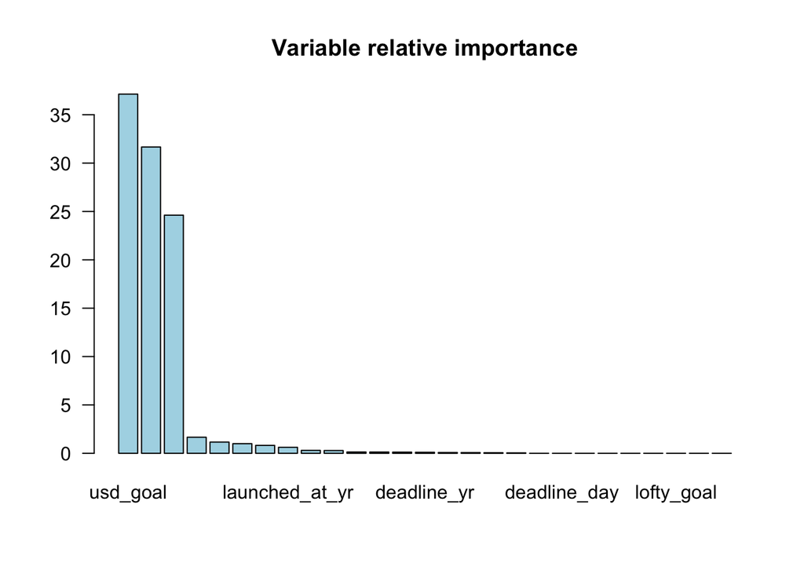

```r
importanceplot(adaboost)
```

```r
t2 <- adaboost$trees[[2]]
library(tree)
```

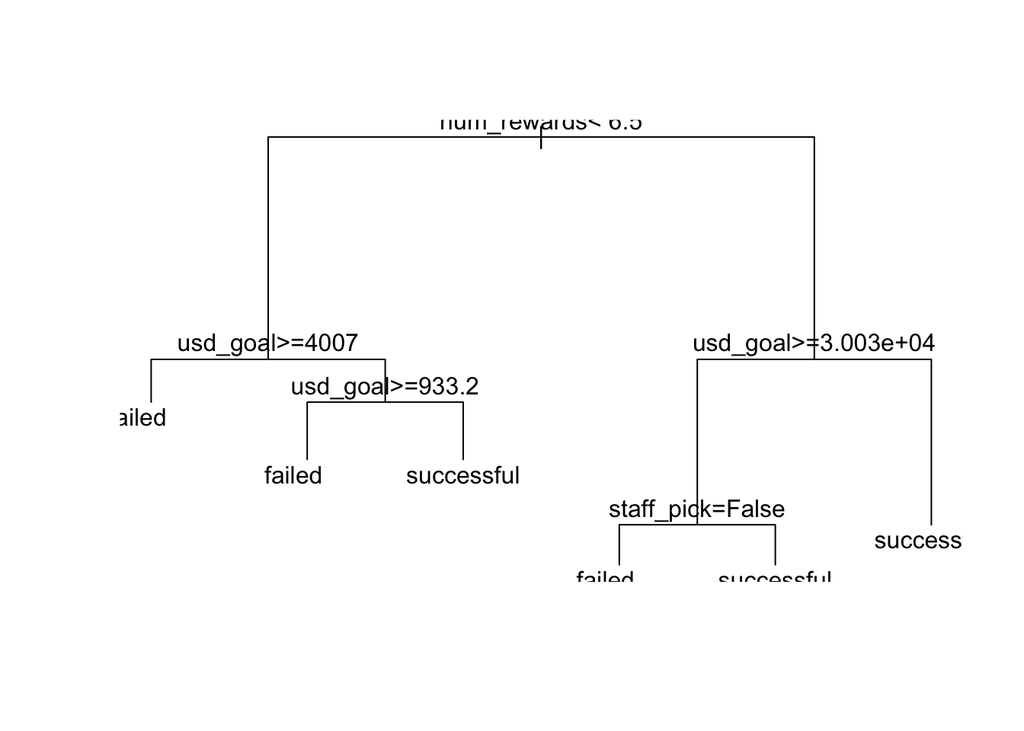

```r
plot(t2)
text(t2, pretty=2)
```

```r
## We can also study the error evolution as boosting moved through each of the 20 weak learners.
errorevol(adaboost, train)
```

```
## $error
##  [1] 0.2428503 0.2428503 0.2311072 0.2310273 0.2294296 0.2257549 0.2249561
##  [8] 0.2187250 0.2229589 0.2197635 0.2207222 0.2191245 0.2190446 0.2168078
## [15] 0.2169676 0.2164883 0.2167279 0.2143314 0.2133727 0.2138521
##
## attr(,"class")
## [1] "errorevol"
```

```r
preds5 <- predict(adaboost,test)

preds5$confusion ## Confusion Matrix for Adaboost
```

```
##                Observed Class
## Predicted Class failed successful
##      failed       1683        424
##      successful    326        696
```

```r
preds5$error ## Error for Adaboost Model
```

```
## [1] 0.2396932
```

Summary of model building/feature engineering: * Tested all different kinds models: KNN, C5.0 and Rpart tree based methods, logistic regression, random forest, and adaboost. Proceeded with RandomForest based on its accuracy. * Tested different combinations of variables, including removing time relation, including some time relation, and ultimately found that time did contribute a slight amount to the model. * Removed variables that a person would not necessarily have control over when creating kickstarter. For example, they wouldn’t be able to control if their project was featured and this also only occurs when a project is successful. This needed to be removed in order to remove significant bias from the model.  
* Further, I realized that I left in both goal and USD_goal, which were obviously very highly correlated, especially since most of the projects use USD.

```r
cor(data2$usd_goal,data2$goal)
```

```
## [1] 0.9960499
```

Next, I decided to remove many of the variables associated with the “launched” date and time as well as the “deadline” date and time. In the random forest importance plot, these variables did not appear to help the model much and I thought they were most likely adding noise to the models. Later, relevant features can be added back into the model.

```r
data4 <- data3  %>% select(-launched_at_weekday, -launched_at_month, -launched_at_day, -launched_at_hr, -launched_at_yr, -LaunchedTuesday, -deadline_weekday, -DeadlineWeekend, -deadline_day, -deadline_month, -deadline_weekday,-deadline_hr, -deadline_yr, -launch_to_deadline_days)

set.seed(3)
samps <- createDataPartition(data4$state, list=F, p =0.8)
train <- data4[samps,]
test <- data4[-samps,]
names(train)
```

```
##  [1] "state"                 "country"
##  [3] "staff_pick"            "name_len"
##  [5] "blurb_len"             "create_to_launch_days"
##  [7] "num_rewards"           "min_reward_USD"
##  [9] "name_sentiment"        "blurb_sentiment"
## [11] "reward_word_change"    "reward_sent_change"
## [13] "tenthousandsonly"      "usd_goal"
## [15] "lofty_goal"
```

```r
myrf <- randomForest(x = train[ , -1],
                     y = train[ , 1],
                     sampsize = round(0.8*dim(train)[1]),
                     ntree = 500,
                     mtry = round(sqrt(dim(train)[2])),
                     importance = TRUE)
```

```r
# summary(myrf)
predsrf <- predict(myrf, newdata=test, type='class')
myrf
```

```
##
## Call:
##  randomForest(x = train[, -1], y = train[, 1], ntree = 500, mtry = round(sqrt(dim(train)[2])),      sampsize = round(0.8 * dim(train)[1]), importance = TRUE)
##                Type of random forest: classification
##                      Number of trees: 500
## No. of variables tried at each split: 4
##
##         OOB estimate of  error rate: 23.49%
## Confusion matrix:
##            failed successful class.error
## failed       6757       1280   0.1592634
## successful   1661       2820   0.3706762
```

```r
tab_rf <- table(predsrf, test$state)
(tab_rf[1,1] + tab[2,2]) / sum(tab_rf)
```

```
## [1] 0.7411314
```

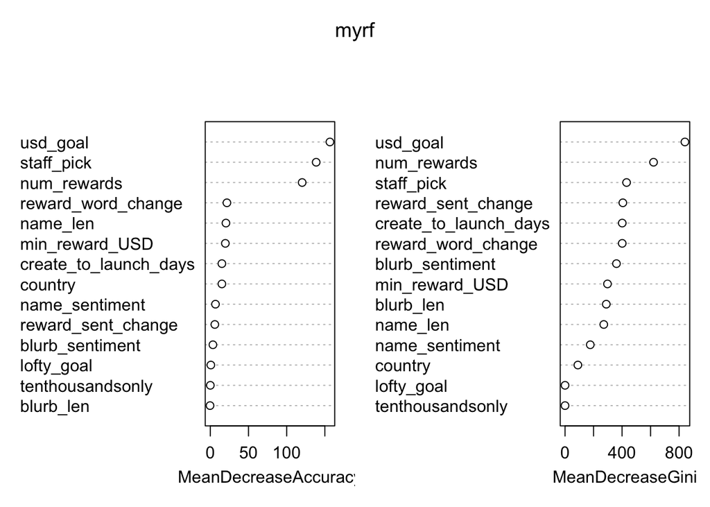

```r
varImpPlot(myrf)
```

```r
predsrf <- predict(myrf)
success_but_p_fail <- train[(predsrf != train$state) & predsrf == "failed",]
failed_but_p_suc <- train[(predsrf != train$state) & predsrf == "successful",]

summary(success_but_p_fail)
```

```
##         state      country   staff_pick      name_len        blurb_len
##  failed    :   0   AU:  39   False:1638   Min.   : 1.000   Min.   : 3.00
##  successful:1661   CA:  81   True :  23   1st Qu.: 4.000   1st Qu.:17.00
##                    GB: 196                Median : 6.000   Median :20.00
##                    NZ:   9                Mean   : 6.113   Mean   :19.08
##                    US:1336                3rd Qu.: 8.000   3rd Qu.:22.00
##                                           Max.   :13.000   Max.   :29.00
##  create_to_launch_days  num_rewards     min_reward_USD
##  Min.   :   0.00       Min.   : 1.000   Min.   :  0.6553
##  1st Qu.:   5.00       1st Qu.: 5.000   1st Qu.:  1.0000
##  Median :  19.00       Median : 7.000   Median :  5.0000
##  Mean   :  56.17       Mean   : 7.709   Mean   : 13.4541
##  3rd Qu.:  51.00       3rd Qu.:10.000   3rd Qu.: 10.0000
##  Max.   :1385.00       Max.   :51.000   Max.   :599.0000
##  name_sentiment     blurb_sentiment   reward_word_change
##  Min.   :-0.69080   Min.   :-0.9042   Min.   :-67.00
##  1st Qu.: 0.00000   1st Qu.: 0.0000   1st Qu.:  0.00
##  Median : 0.00000   Median : 0.2294   Median :  8.00
##  Mean   : 0.09371   Mean   : 0.2502   Mean   : 13.73
##  3rd Qu.: 0.12500   3rd Qu.: 0.4757   3rd Qu.: 24.00
##  Max.   : 0.89570   Max.   : 0.9682   Max.   :187.00
##  reward_sent_change tenthousandsonly    usd_goal      lofty_goal
##  Min.   :-1.06160   Min.   :0        Min.   :     1   FALSE:1661
##  1st Qu.:-0.34573   1st Qu.:0        1st Qu.:  3143   TRUE :   0
##  Median :-0.04422   Median :0        Median : 10000
##  Mean   :-0.10253   Mean   :0        Mean   : 22518
##  3rd Qu.: 0.07283   3rd Qu.:0        3rd Qu.: 25205
##  Max.   : 1.07997   Max.   :0        Max.   :349750
```

```r
summary(failed_but_p_suc)
```

```
##         state      country  staff_pick     name_len        blurb_len
##  failed    :1280   AU: 30   False:990   Min.   : 1.000   Min.   : 2.00
##  successful:   0   CA: 58   True :290   1st Qu.: 5.000   1st Qu.:17.00
##                    GB:203               Median : 7.000   Median :20.00
##                    NZ:  5               Mean   : 6.552   Mean   :19.34
##                    US:984               3rd Qu.: 8.000   3rd Qu.:22.00
##                                         Max.   :14.000   Max.   :30.00
##  create_to_launch_days  num_rewards     min_reward_USD
##  Min.   :   0.00       Min.   : 1.000   Min.   :  0.6996
##  1st Qu.:   6.00       1st Qu.: 6.000   1st Qu.:  1.0000
##  Median :  19.00       Median : 8.000   Median :  5.0000
##  Mean   :  53.66       Mean   : 9.363   Mean   :  8.7636
##  3rd Qu.:  53.00       3rd Qu.:11.000   3rd Qu.: 10.0000
##  Max.   :1126.00       Max.   :55.000   Max.   :397.0000
##  name_sentiment    blurb_sentiment   reward_word_change reward_sent_change
##  Min.   :-0.8316   Min.   :-0.8658   Min.   :-104.00    Min.   :-1.63220
##  1st Qu.: 0.0000   1st Qu.: 0.0000   1st Qu.:   0.00    1st Qu.:-0.34485
##  Median : 0.0000   Median : 0.2553   Median :  10.00    Median :-0.07274
##  Mean   : 0.0891   Mean   : 0.2553   Mean   :  15.59    Mean   :-0.09707
##  3rd Qu.: 0.1027   3rd Qu.: 0.4721   3rd Qu.:  26.00    3rd Qu.: 0.10275
##  Max.   : 0.8779   Max.   : 0.9571   Max.   : 250.00    Max.   : 1.01820
##  tenthousandsonly    usd_goal      lofty_goal
##  Min.   :0        Min.   :     1   FALSE:1280
##  1st Qu.:0        1st Qu.:  1557   TRUE :   0
##  Median :0        Median :  4530
##  Mean   :0        Mean   : 19863
##  3rd Qu.:0        3rd Qu.: 15648
##  Max.   :0        Max.   :900000
```

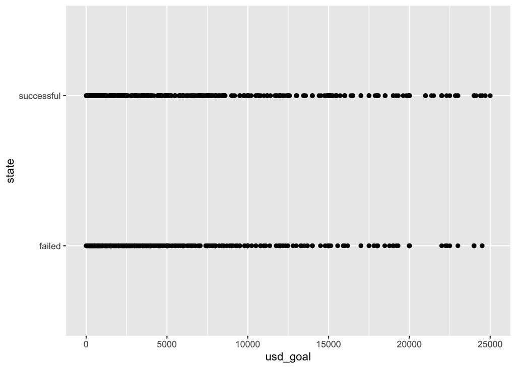

```r
messed_up <- train[(predsrf != train$state),]

messed_up_small <- messed_up %>% filter(usd_goal < 25000)
ggplot(data=messed_up_small) + geom_point(aes(y=state,x=usd_goal))
```

```r
## let's create a new threshold at 20000 for the funding goal. It appears that a good majority of points for successful campaigns fell under this threshold, even though they were predicted as failed.
data4$goalthresh <- as.factor(ifelse(data4$usd_goal, 1, 0))
```

In addition to testing out this new threshold, I am going to remove the features for very high goals (lofty_goal) and strangely high and flat (all rewards were $10,000) incentive structures (tenthousandsonly).

```r
data5 <- data4  %>% select(-lofty_goal, -tenthousandsonly )

set.seed(3)
names(data5)
```

```
##  [1] "state"                 "country"
##  [3] "staff_pick"            "name_len"
##  [5] "blurb_len"             "create_to_launch_days"
##  [7] "num_rewards"           "min_reward_USD"
##  [9] "name_sentiment"        "blurb_sentiment"
## [11] "reward_word_change"    "reward_sent_change"
## [13] "usd_goal"              "goalthresh"
```

```r
samps <- createDataPartition(data5$state, list=F, p =0.8)
train <- data5[samps,]
test <- data5[-samps,]
names(train)
```

```
##  [1] "state"                 "country"
##  [3] "staff_pick"            "name_len"
##  [5] "blurb_len"             "create_to_launch_days"
##  [7] "num_rewards"           "min_reward_USD"
##  [9] "name_sentiment"        "blurb_sentiment"
## [11] "reward_word_change"    "reward_sent_change"
## [13] "usd_goal"              "goalthresh"
```

```r
myrf <- randomForest(x = train[ , -1],
                     y = train[ , 1],
                     sampsize = round(0.8*dim(train)[1]),
                     ntree = 500,
                     mtry = round(sqrt(dim(train)[2])),
                     importance = TRUE)
myrf
```

```
##
## Call:
##  randomForest(x = train[, -1], y = train[, 1], ntree = 500, mtry = round(sqrt(dim(train)[2])),      sampsize = round(0.8 * dim(train)[1]), importance = TRUE)
##                Type of random forest: classification
##                      Number of trees: 500
## No. of variables tried at each split: 4
##
##         OOB estimate of  error rate: 23.57%
## Confusion matrix:
##            failed successful class.error
## failed       6764       1273   0.1583924
## successful   1678       2803   0.3744700
```

```r
predsrf <- predict(myrf, newdata=test, type='class')
myrf
```

```
##
## Call:
##  randomForest(x = train[, -1], y = train[, 1], ntree = 500, mtry = round(sqrt(dim(train)[2])),      sampsize = round(0.8 * dim(train)[1]), importance = TRUE)
##                Type of random forest: classification
##                      Number of trees: 500
## No. of variables tried at each split: 4
##
##         OOB estimate of  error rate: 23.57%
## Confusion matrix:
##            failed successful class.error
## failed       6764       1273   0.1583924
## successful   1678       2803   0.3744700
```

```r
tab_rf <- table(predsrf, test$state)
(tab_rf[1,1] + tab[2,2]) / sum(tab_rf)
```

```
## [1] 0.7436881
```

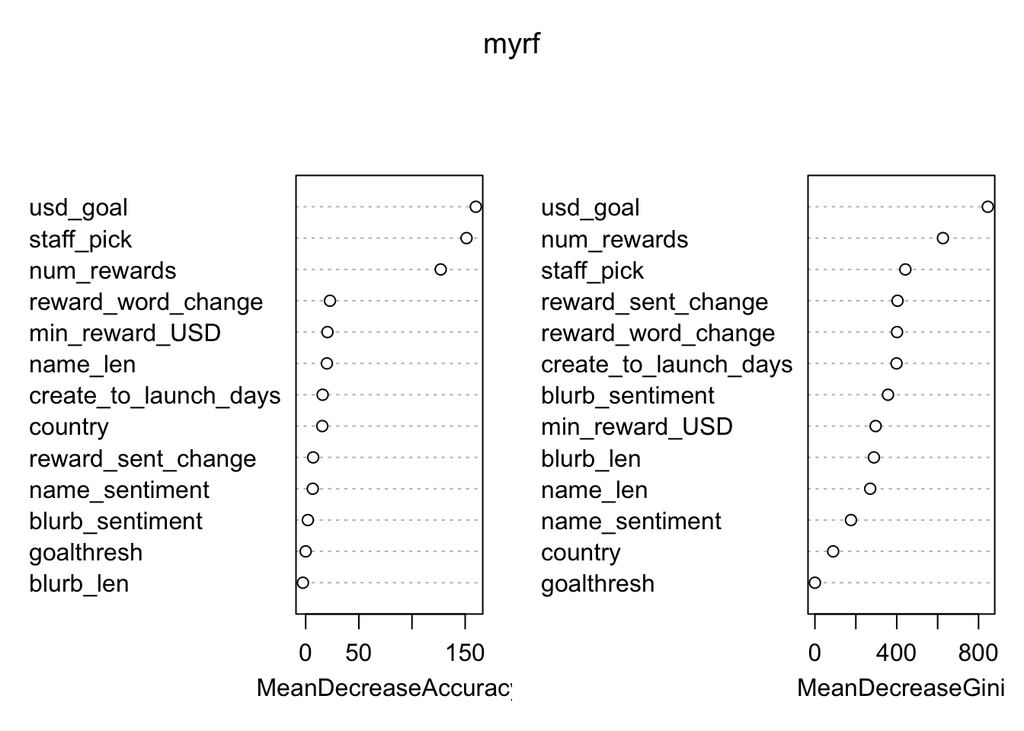

```r
varImpPlot(myrf)
```

After testing this out for a little bit, it was clear that some of the older variable combinations produced better model. With the following code I ran a grid search to find the optimal combination of hyperparameters. This was found to be a cp of 0.1 and with ntree = 1000.

```r
# seed = 2
# control <- trainControl(method="repeatedcv", number=5, repeats=0, search="grid")
# tunegrid <- expand.grid(.mtry=c(sqrt(ncol(data3))))
# metric = "Accuracy"
# modellist <- list()
# for (cp in c(.001, .01, 0.1)) {
#   for (ntree in c(500,1000,1500)) {
#   set.seed(seed)
#   fit <- train(state~., data=data3, method="rf", metric=metric, tuneGrid=tunegrid, trControl=control, ntree=ntree, cp=cp)
#   key <- paste(cp,ntree, sep = "_")
#   modellist[[key]] <- fit
#   }
# }
# # compare results
# results <- resamples(modellist)
# summary(results)
# dotplot(results)
```

```r
set.seed(1)
samps <- createDataPartition(data3$state, list=F, p =0.8)
train <- data3[samps,]
test <- data3[-samps,]

myrf <- randomForest(x = train[ , -1],
                     y = train[ , 1],
                     sampsize = round(0.8*dim(train)[1]),
                     ntree = 1000,
                     mtry = round(sqrt(dim(train)[2])),
                     cp = 0.1,
                     importance = TRUE)
myrf
```

```
##
## Call:
##  randomForest(x = train[, -1], y = train[, 1], ntree = 1000, mtry = round(sqrt(dim(train)[2])),      sampsize = round(0.8 * dim(train)[1]), importance = TRUE,      cp = 0.1)
##                Type of random forest: classification
##                      Number of trees: 1000
## No. of variables tried at each split: 5
##
##         OOB estimate of  error rate: 22.12%
## Confusion matrix:
##            failed successful class.error
## failed       7014       1023   0.1272863
## successful   1746       2735   0.3896452
```

```r
preds_final <- predict(myrf, newdata = test, type="class")
mean(preds_final  == test$state)
```

```
## [1] 0.7654203
```

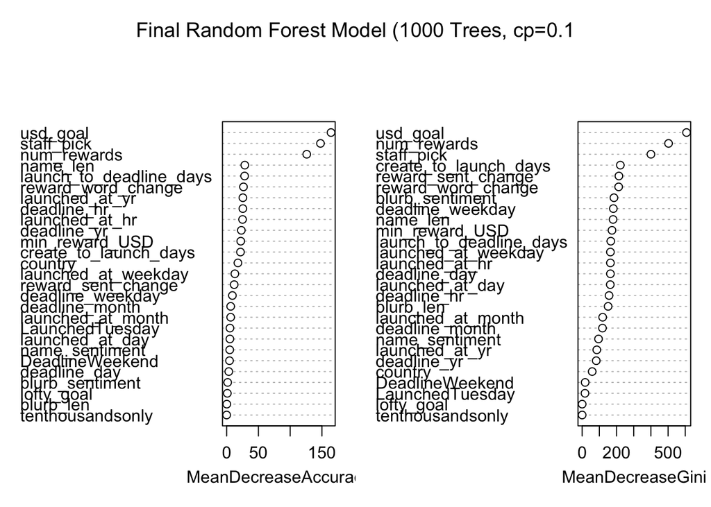

```r
varImpPlot(myrf, main = 'Final Random Forest Model (1000 Trees, cp=0.1')
```

## Conclusions From the results of our Random Forest model, we find that the most important factor in predicting success for these kickstarter campaigns is the goal. Having lofty goals appears to delegitimize your project, as many more fail that have high goals than succeed. Being staff picked was also a large contributing factor to success. Having the elevated platform of being chosen by someone at Kickstarter does seem to reap benefits. Lastly, the third principal variable in distinguishing successful campaigns is the number of rewards. It is also important to note that many of the sentiment variables created were not actually that useful in the model. I find it pretty surprising that the number of rewards is more important in the determination of success and failure than sentiment, but it goes to show you how important those rewards were to include in the model. People really seem to be driven by these types of incentives based on these results.

## Next Steps

This project can be improved in several ways in the future. The first suggestion for improvement would be to try to successfully completely capture the complete project descriptions for each observations. As I stated at the beginning, I was only able to collect around 50% of these data. With this additionally textual information, new features could be created to determine how sentiment of the actual project text plays a role in these projects. A few features that might be interesting to explore would be to count the number of people mentioned in the story, to analyze discrepancies in the sentiment between both the actual project description and the section of the description titled “risks and challenges”. How do these relate to each other? Do people actually like hearing honest and potentally more negative language in the risks and challenges or do they prefer higher confidence in this section? A second improvement could also be to develop a way to analyze imagery, including that in the thumbnails, background, and, perhaps most importantly, videos. Many projects use beautiful imagery to help promote their product. Perhaps their would be a way to classify these as more or less aesthetically pleasing and see if this categorization trends with success or failure. Lastly, I would recommend applying emotional analysis as well. It is easy to forget that polarity is simply measuring positive and negative reaction to words. How does the actual emotional content of the text contribute to the success or failure of the project? Do different categories see different levels of success depending on their emotional balance? For example, do gaming projects tend to do better with a more joyous and exciting language compared to art projects? Questions like these would be interesting to explore in the future.